# Stats 250: Lab 3 Assignment - Solutions

Replace this text with your name(s)

Week of February 13th

### Instructions

Complete the lab exercises and Dive Deeper questions below. Lab exercises will be graded out of 2 points each and the Dive Deeper questions will be graded out of 3 points each - all of them will be graded for *correctness*. Upon completion, follow the submission instructions at the bottom of this document. We strongly encourage you to work on this assignment with a partner.

### Background

[Source](https://www.kaggle.com/datasets/stefanoleone992/fifa-22-complete-player-dataset)

FIFA is a popular soccer video game developed by EA Sports. Listed as the best-selling sports video game in the world, FIFA allows gamers to play soccer matches using real players from all over the world. This data set contains information for **every** soccer player competing in the MLS (the most popular soccer league in the US). In other words, this data set contains *the population of all soccer players in the MLS*. (Note: goalkeepers have been removed.) The original file contains over 50 attributes for every player, but we have narrowed it down to the following eight variables.

1. `club`: team
2. `positions`: a list of positions for the player
3. `height`: height (in cm)
4. `salary`: annual salary (in $1000’s)
5. `speed`: speed (out of 100)
6. `shooting`: shooting ability (out of 100)
7. `dribbling`: dribbling ability (out of 100)
8. `defending`: defending ability (out of 100)

Note: the number (1-8) corresponds to the column number of the variable

Use the following code chunk to read in the data set.

```r
fifa <- read.csv("fifa.csv", row.names = 1)
```

You can preview the data below.

```r
head(fifa)
```

```
##                                         club positions height salary speed
## Aaron Herrera                 Real Salt Lake    RB, LB    180 111.28    68
## Aaron Long                New York Red Bulls        CB    185 500.76    80
## Aaron Maxwell Schoenfeld           Austin FC        ST    193 111.28    62
## Abdoulaye Cissoko        Seattle Sounders FC        CB    191  50.08    61
## Aboubacar Kobele Keita         Columbus Crew        CB    189  55.64    80
## Abu Danladi                     Nashville SC    ST, RM    178 111.28    76
##                          shooting dribbling defending
## Aaron Herrera                  32        62        65
## Aaron Long                     40        64        74
## Aaron Maxwell Schoenfeld       61        58        29
## Abdoulaye Cissoko              28        45        57
## Aboubacar Kobele Keita         27        50        63
## Abu Danladi                    63        64        39
```

And be sure to load in the required packages!

```r
library(ggplot2)
library(ggdist)
library(stats250package)
```

### Lab Exercises

After reading in the data set above, complete the following lab exercise. Remember, these exercises are worth 2 points each and are graded for correctness.

> **1.** Create a histogram for the heights of the MLS soccer players. Be sure to include appropriate axis labels and a title. Comment on the shape, center, and spread of the histogram.

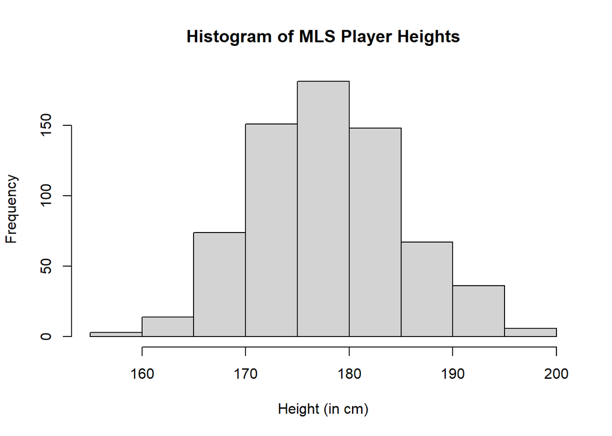

```r
hist(fifa$height,
     xlab = "Height (in cm)",
     main = "Histogram of MLS Player Heights")
```

*Answer:* The histogram of MLS player heights is bell-shaped (or normally distributed - and unimodal, symmetric). The center is around 175 - 180 cm (ish) and the range of the data is from about 155 cm to 200 cm. *We are looking for some idea of normality - coupled with some approximation of center and spread (nothing specific, but students are welcome to calculate exact numerical summaries!).*

> **2.** With the height variable and the `samplingDistXbar()` fuction, create the sampling distribution of the sample mean for random samples of size *4*. What does each dot in the plot represent? Be specific and provide context!

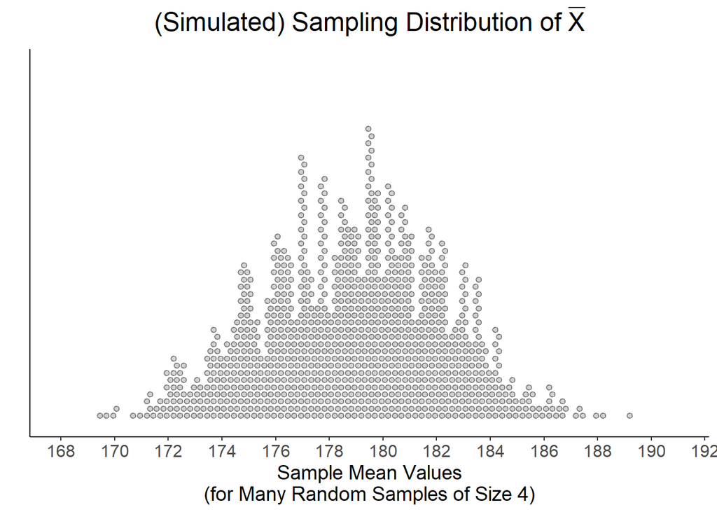

```r
samplingDistXbar(data = fifa, n = 4, column = 3)
```

*Answer:* Each dot represents the sample mean height calculated from a random sample of 4 MLS soccer players. *Looking for some idea of average, a sample size of 4, and some context.*

> **3.** With the height variable and the `samplingDistXbar()` fuction, create the sampling distribution of the sample mean for random samples of size *16*. With this plot (and the plot from Exercise 2), you should find a bell-shaped distribution. The Central Limit Theorem says that we need to take random samples of at least size 25 in order for the resulting sampling distribution to be approximately normal - so why are these plots normal even though we have smaller sample sizes?

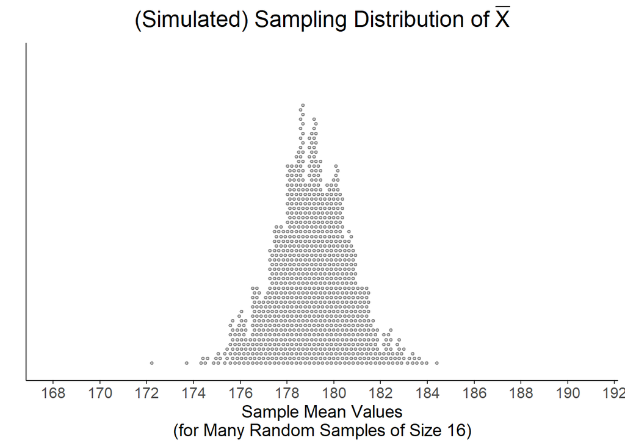

```r
samplingDistXbar(data = fifa, n = 16, column = 3)
```

*Answer:* These sampling distributions are normally distributed because the original variable was normally distributed - so the CLT was not needed here. (If the original histogram in Exercise 1 had been skewed, then these plots may not have been bell-shaped.) *Some idea that the heights variable was normal.*

> **4.** Pick a different quantitative variable from the FIFA data set. Create a histogram for your chosen variable. Be sure to include appropriate axis labels and a title. Comment on the shape of the histogram (you’ll be calculating the mean and standard deviation in Exercise 5, so no need to comment on the center or spread).

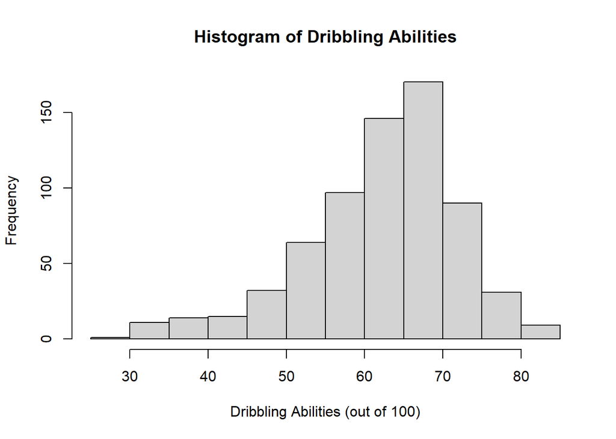

```r
hist(fifa$dribbling,
     xlab = "Dribbling Abilities (out of 100)",
     main = "Histogram of Dribbling Abilities")
```

*Answer:* The distribution of dribbling abilities is skewed to the left. *Just looking for a brief measure of shape. Most of the variables should have some skew to them.*

> **5.** Calculate the mean and standard deviation for the variable you picked in Exercise 4. Would these values be considered parameters (mu and sigma, respectively) or statistics (xbar and s, respectively)? Explain why. Reread the background if you’re not sure!

```r
mean(fifa$dribbling)
```

```
## [1] 62.59412
```

```r
sd(fifa$dribbling)
```

```
## [1] 9.739159
```

*Answer:* These are parameters because we have data for every MLS player. *Some idea of all or population of every player, etc.*

> **6.** With the variable you picked in Exercise 4 and the `samplingDistXbar()` fuction, create the sampling distribution of the sample mean for random samples of size *25*. What does each dot in the plot represent? Be specific and provide context!

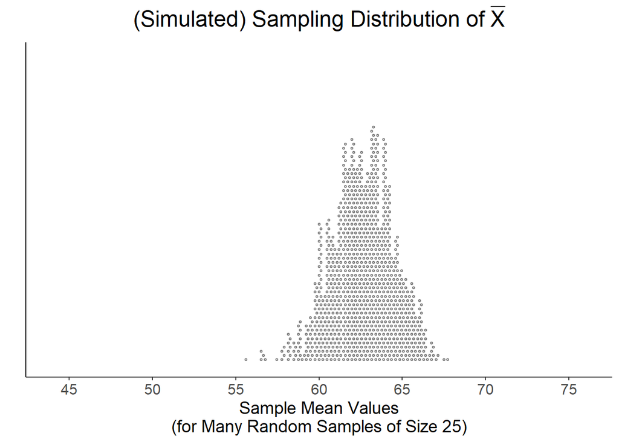

```r
samplingDistXbar(data = fifa, n = 25, column = 7)
```

*Answer:* Each dot represents the sample mean dribbling ability calculated from a random sample of 25 MLS soccer players. *Looking for some idea of average, a sample size of 25, and some context.*

> **7.** With the variable you picked in Exercise 4 and the `samplingDistXbar()` fuction, create the sampling distribution of the sample mean for random samples of size *100*. How do the shapes, centers, and spreads of this plot and the plot from Exercise 6 compare?

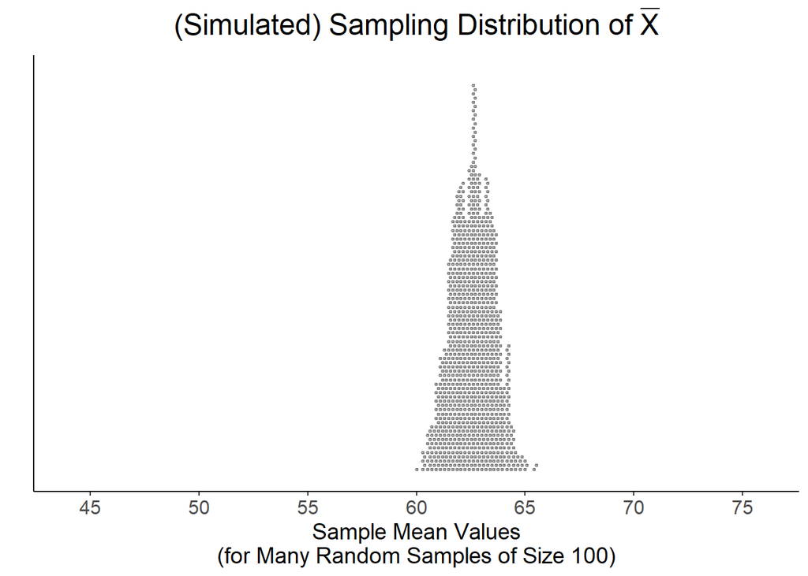

```r
samplingDistXbar(data = fifa, n = 100, column = 7)
```

*Answer:* Both plots are normal (or approximately bell-shaped) and both plots are centered around a value of about 63. The spread of the second plot is smaller than the spread of the first. *Looking for a comparison of all three aspects.*

### Dive Deeper Questions

After completing the lab exercises above, complete the following Dive Deeper questions. Remember, these questions are worth 3 points each and are graded for correctness.

> **1.** What is more likely - observing an average height of *at least* 174 cm for a random sample of 4 MLS players or for a random sample of 16 MLS players? Explain your reasoning.

*Answer:* It is more likely to observe an average height of at least 174 cm for a random sample of *16* MLS players. As seen in the sampling distributions above, almost every sample mean is larger than 174 cm for the plot when n = 16. The variability of the sampling distribution decreased when the sample size is larger - so the probability will be greater when n = 16. *Many ways to support this idea - using the simulated sampling distributions, calculating the actual probabilities, discussing the variability of the sampling distribution, etc.*

> **2.** Another variable included in the original data set was *overall* - which measures the overall skill of a player (out of 100). The sampling distribution of the sample mean for random samples of size *50* was created and is provided below. The sampling distribution is bell-shaped, but what about the original overall variable…Can we determine if the shape of the histogram for overall skill is also normally distributed? In other words, if we were to plot the histogram of the variable overall skill for all 680 MLS players, do we know (based on the sampling distribution provided) whether the histogram will follow a normal distrbution? Why or why not?

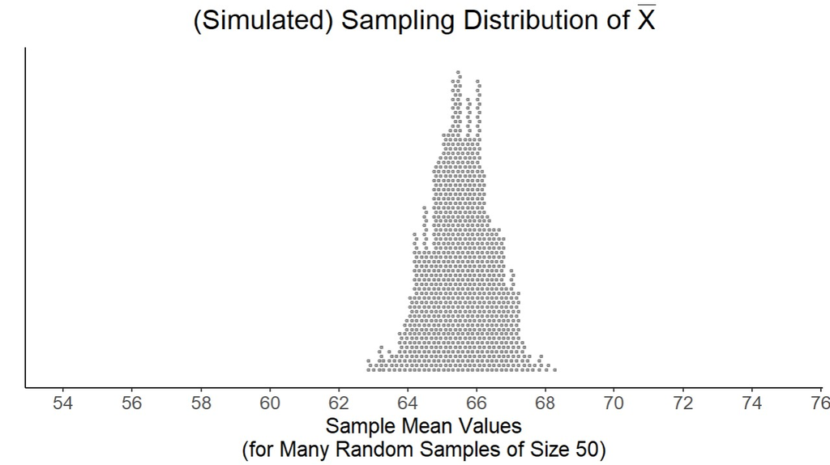

*Answer:* Based on this plot, we cannot determine if the distribution of overall skill was normally distributed. With n = 50, the sample size is large enough to use the Central Limit Theorem (CLT) - meaning that the original distribution could have been skewed, symmteric, bimodal, etc. and the sampling distribution would still look normal or approximately normal. *Some idea here that the CTL would ensure normality*

### Submission Instructions

Once you have finished, follow the instructions below to submit your work.

1. At the top of the document, update the `author` field. Do not change anything else at the top of the document.
2. Click the Knit button to create an HTML file of your work.
3. In the Files pane (bottom right window), check the box next to `lab03assignment.html`.
4. In the Files pane, click on the gear icon (More) and select “Export…”
5. Do not change the file name (`lab03assignment.html`). Click Download and save the file to your computer.
6. On the Stats 250 Canvas site, navigate to the Lab 3 assignment.
7. Upload your saved `lab03assignment.html` file.
8. Click “Submit Assignment”. Congratulations, you are done with Lab 3!